# Assignment 3

The US Department of Agriculture publishes price estimates for fruits and vegetables [online](https://www.ers.usda.gov/data-products/fruit-and-vegetable-prices/fruit-and-vegetable-prices/). The most recent estimates are based on a 2013 survey of US retail stores.

The estimates are provided as a collection of MS Excel files, with one file per fruit or vegetable. The `assignment3_data.zip` file contains the fruit and vegetable files in the directories `fruit` and `vegetables`, respectively.

```python
%reset
import pandas as pd
import numpy as np
import matplotlib
import matplotlib.pyplot as plt
```

```
Once deleted, variables cannot be recovered. Proceed (y/[n])? y
```

**Exercise 1.1.** Use pandas to extract the "Fresh" row(s) from the **fruit** Excel files. Combine the data into a single data frame. Your data frame should look something like this:

| type | food | form | price_per_lb | yield | lb_per_cup | price_per_cup |
| --- | --- | --- | --- | --- | --- | --- |
| fruit | watermelon | Fresh1 | 0.333412 | 0.52 | 0.330693 | 0.212033 |
| fruit | cantaloupe | Fresh1 | 0.535874 | 0.51 | 0.374786 | 0.3938 |
| vegetables | onions | Fresh1 | 1.03811 | 0.9 | 0.35274 | 0.406868 |
| ... |  |  |  |  |  |  |

It's okay if the rows and columns of your data frame are in a different order. These modules are especially relevant:

- [`str` methods](https://docs.python.org/2/library/stdtypes.html#string-methods)
- [`os`](https://docs.python.org/2/library/os.html)
- [`os.path`](https://docs.python.org/2/library/os.path.html)
- [pandas](http://pandas.pydata.org/pandas-docs/stable/): `read_excel()`, `concat()`, `.fillna()`, `.str`, plotting methods

Ask questions and search the documentation/web to find the functions you need.

```python
from os import listdir
from os import chdir
from os.path import isfile, join
chdir('../homework/assignment3_data/fruit/') #change directory
onlyfiles = [f for f in listdir('../fruit/') if isfile(join('../fruit/', f))] # list all files
#http://stackoverflow.com/questions/3207219/how-to-list-all-files-of-a-directory-in-python

temp = pd.DataFrame() #empty dataframe

for i in range(0, len(onlyfiles)):
    fruitfile = pd.read_excel(onlyfiles[i], header = None, index = False) #read each file
    fruitrow = fruitfile[0:1].head() #get first row
    fruitname = fruitrow[0]
    fruitname = str(fruitname) #convert to str
    fruitname = fruitname[1:]
    fruitname = fruitname.strip()
    name = fruitname.split("\xe2") #split
    strname = name[0] #get name of food
    freshrow = fruitfile[3:4] #get fresh row
    freshrow2 = str(freshrow)
    freshrow2 = freshrow2.strip()
    a = freshrow2.split('\n')[1]
    fresh1 = a.split("  ")[1]
    if (fresh1 == 'Fresh1'):
    #only add to dataframe if it's fresh
        #add name to the dataframe
        name = pd.DataFrame({'nameoffruit':[strname], 'type': 'fruit'}, index = [3])
        frames = [name, freshrow]
        newnew = pd.concat(frames, axis = 1)
        #concatenate new row to previous dataframe
        tempframe = [temp, newnew]
        dat = pd.concat(tempframe, axis = 0)
        temp = dat #put dataframe into temp

dat = dat.drop(dat.columns[[2, 5, 7, 8]], axis = 1)
#rename columns
dat.columns = ['form', 'price_per_pound', 'yield_', 'lb_per_cup', 'price_per_cup', 'food', 'typ']
dat[['price_per_pound', 'yield_', 'lb_per_cup', 'price_per_cup']] = dat[['price_per_pound', 'yield_', 'lb_per_cup', 'price_per_cup']].astype(float)
fruitdf = dat[['food', 'typ','form', 'price_per_pound', 'yield_', 'lb_per_cup', 'price_per_cup']]
fruitdf
```

|  | food | typ | form | price_per_pound | yield_ | lb_per_cup | price_per_cup |
| --- | --- | --- | --- | --- | --- | --- | --- |
| 3 | Apples | fruit | Fresh1 | 1.567515 | 0.90 | 0.242508 | 0.422373 |
| 3 | Apricots | fruit | Fresh1 | 3.040072 | 0.93 | 0.363763 | 1.189102 |
| 3 | Bananas | fruit | Fresh1 | 0.566983 | 0.64 | 0.330693 | 0.292965 |
| 3 | Blackberries | fruit | Fresh1 | 5.774708 | 0.96 | 0.319670 | 1.922919 |
| 3 | Blueberries | fruit | Fresh1 | 4.734622 | 0.95 | 0.319670 | 1.593177 |
| 3 | Cantaloupe | fruit | Fresh1 | 0.535874 | 0.51 | 0.374786 | 0.393800 |
| 3 | Cherries | fruit | Fresh1 | 3.592990 | 0.92 | 0.341717 | 1.334548 |
| 3 | Grapefruit | fruit | Fresh1 | 0.897802 | 0.49 | 0.462971 | 0.848278 |
| 3 | Grapes | fruit | Fresh1 | 2.093827 | 0.96 | 0.330693 | 0.721266 |
| 3 | Honeydew melon | fruit | Fresh1 | 0.796656 | 0.46 | 0.374786 | 0.649077 |
| 3 | Kiwi | fruit | Fresh1 | 2.044683 | 0.76 | 0.385809 | 1.037970 |
| 3 | Mangoes | fruit | Fresh1 | 1.377563 | 0.71 | 0.363763 | 0.705783 |
| 3 | Nectarines | fruit | Fresh1 | 1.761148 | 0.91 | 0.319670 | 0.618667 |
| 3 | Oranges | fruit | Fresh1 | 1.035173 | 0.73 | 0.407855 | 0.578357 |
| 3 | Papaya | fruit | Fresh1 | 1.298012 | 0.62 | 0.308647 | 0.646174 |
| 3 | Peaches | fruit | Fresh1 | 1.591187 | 0.96 | 0.341717 | 0.566390 |
| 3 | Pears | fruit | Fresh1 | 1.461575 | 0.90 | 0.363763 | 0.590740 |
| 3 | Pineapple | fruit | Fresh1 | 0.627662 | 0.51 | 0.363763 | 0.447686 |
| 3 | Plums | fruit | Fresh1 | 1.827416 | 0.94 | 0.363763 | 0.707176 |
| 3 | Pomegranate | fruit | Fresh1 | 2.173590 | 0.56 | 0.341717 | 1.326342 |
| 3 | Raspberries | fruit | Fresh1 | 6.975811 | 0.96 | 0.319670 | 2.322874 |
| 3 | Strawberries | fruit | Fresh1 | 2.358808 | 0.94 | 0.319670 | 0.802171 |
| 3 | Tangerines | fruit | Fresh1 | 1.377962 | 0.74 | 0.407855 | 0.759471 |
| 3 | Watermelon | fruit | Fresh1 | 0.333412 | 0.52 | 0.330693 | 0.212033 |

**Exercise 1.2.** Reuse your code from exercise 1.1 to extract the "Fresh" row(s) from the **vegetable** Excel files.

Does your code produce the correct prices for tomatoes? If not, why not? Do any other files have the same problem as the tomatoes file?

You don't need to extract the prices for these problem files. However, make sure the prices are extracted for files like asparagus that don't have this problem.

```python
from os.path import isfile, join
chdir('../vegetables/') #change dir
onlyfiles = [f for f in listdir('../vegetables/') if isfile(join('../vegetables/', f))] #get all files
#http://stackoverflow.com/questions/3207219/how-to-list-all-files-of-a-directory-in-python

temp = pd.DataFrame() #empty dataframe

for i in range(0, len(onlyfiles)):
    fruitfile = pd.read_excel(onlyfiles[i], header = None, index = False) #read each file
    fruitrow = fruitfile[0:1].head() #get first row
    fruitname = fruitrow[0]
    fruitname = str(fruitname) #convert to str
    fruitname = fruitname[1:]
    fruitname = fruitname.strip()
    name = fruitname.split("\xe2") #get name
    strname = name[0] #get name
    freshrow = fruitfile[3:4]
    freshrow2 = str(freshrow) #the following gets the type of food
    freshrow2 = freshrow2.strip()
    a = freshrow2.split('\n')[1]
    fresh1 = a.split("  ")[1]

    #check if fresh
    if (fresh1 == 'Fresh1' or fresh1 == 'Fresh' or strname == "Cabbage" or strname == "Cucumbers"):
        name = pd.DataFrame({'nameoffruit':[strname], 'type': 'vegetable'}, index = [3])
        frames = [name, freshrow]
        newnew = pd.concat(frames, axis = 1)
        tempframe = [temp, newnew] #concatenate with previous df
        dat = pd.concat(tempframe, axis = 0)
        temp = dat

    if (strname == 'Cabbage' or strname == 'Cucumbers'):
        freshrow = fruitfile[4:5]
        freshrow2 = str(freshrow)
        freshrow2 = freshrow2.strip()
        a = freshrow2.split('\n')[1]
        fresh1 = a.split("  ")[1]
        name = pd.DataFrame({'nameoffruit':[strname], 'type': 'vegetable'}, index = [4])
        frames = [name, freshrow]
        newnew = pd.concat(frames, axis = 1)
        tempframe = [temp, newnew] #concatenate with previos df
        dat = pd.concat(tempframe, axis = 0)
        temp = dat

#name columns
dat = dat.drop(dat.columns[[4, 7]], axis = 1)
dat.columns = ['food', 'typ', 'form', 'price_per_pound', 'yield_', 'lb_per_cup', 'price_per_cup']
dat
```

|  | food | typ | form | price_per_pound | yield_ | lb_per_cup | price_per_cup |
| --- | --- | --- | --- | --- | --- | --- | --- |
| 3 | Acorn squash | vegetable | Fresh1 | 1.17225 | 0.458554 | 0.451948 | 1.15536 |
| 3 | Artichoke | vegetable | Fresh1 | 2.21305 | 0.375309 | 0.385809 | 2.27497 |
| 3 | Asparagus | vegetable | Fresh1 | 3.21349 | 0.493835 | 0.396832 | 2.58227 |
| 3 | Avocados | vegetable | Fresh1 | 2.23587 | 0.740753 | 0.31967 | 0.964886 |
| 3 | Broccoli | vegetable | Fresh |  |  |  | NaN |
| 3 | Brussels sprouts | vegetable | Fresh1 | 2.76355 | 1.06 | 0.341717 | 0.890898 |
| 3 | Butternut squash | vegetable | Fresh1 | 1.24474 | 0.714 | 0.451948 | 0.787893 |
| 3 | Cabbage | vegetable | Fresh green cabbage1 | 0.579208 | 0.778797 | 0.330693 | 0.245944 |
| 4 | Cabbage | vegetable | Fresh red cabbage1 | 1.05645 | 0.779107 | 0.330693 | 0.448412 |
| 3 | Carrots | vegetable | Fresh | NaN | NaN | NaN | NaN |
| 3 | Cauliflower | vegetable | Fresh1 |  |  |  | NaN |
| 3 | Celery | vegetable | Fresh1 | NaN | NaN | NaN | NaN |
| 3 | Collard greens | vegetable | Fresh1 | 2.63084 | 1.16 | 0.286601 | 0.650001 |
| 3 | Sweet corn | vegetable | Fresh1 | 2.69062 | 0.54 | 0.363763 | 1.8125 |
| 3 | Cucumbers | vegetable | Fresh, consumed with peel1 | 1.29593 | 0.97 | 0.264555 | 0.353448 |
| 4 | Cucumbers | vegetable | Fresh, peeled1 | 1.29593 | 0.73 | 0.264555 | 0.46965 |
| 3 | Green beans | vegetable | Fresh1 | 2.13997 | 0.846575 | 0.275578 | 0.696606 |
| 3 | Green peppers | vegetable | Fresh1 | 1.41036 | 0.82 | 0.264555 | 0.455022 |
| 3 | Kale | vegetable | Fresh1 | 2.8073 | 1.05 | 0.286601 | 0.766262 |
| 3 | Iceberg lettuce | vegetable | Fresh1 | 1.21304 | 0.95 | 0.242508 | 0.309655 |
| 3 | Romaine lettuce | vegetable | Fresh1 |  | NaN |  | NaN |
| 3 | Mushrooms | vegetable | Fresh1 | NaN | NaN | NaN | NaN |
| 3 | Mustard greens | vegetable | Fresh1 | 2.56924 | 0.84 | 0.308647 | 0.944032 |
| 3 | Okra | vegetable | Fresh1 | 3.21355 | 0.769474 | 0.35274 | 1.47315 |
| 3 | Onions | vegetable | Fresh1 | 1.03811 | 0.9 | 0.35274 | 0.406868 |
| 3 | Potatoes | vegetable | Fresh1 | 0.56432 | 0.811301 | 0.264555 | 0.184017 |
| 3 | Radish | vegetable | Fresh1 | 1.31163 | 0.9 | 0.275578 | 0.401618 |
| 3 | Red peppers | vegetable | Fresh1 | 2.27794 | 0.82 | 0.264555 | 0.734926 |
| 3 | Spinach | vegetable | Fresh1 | NaN | NaN | NaN | NaN |
| 3 | Summer squash | vegetable | Fresh1 | 1.63948 | 0.7695 | 0.396832 | 0.84548 |
| 3 | Sweet potatoes | vegetable | Fresh1 | 0.918897 | 0.811301 | 0.440925 | 0.4994 |
| 3 | Tomatoes | vegetable | Fresh | NaN | NaN | NaN | NaN |
| 3 | Turnip greens | vegetable | Fresh1 | 2.47175 | 0.75 | 0.31967 | 1.05353 |

**Exercise 1.3.** Remove rows without a price from the vegetable data frame and then combine the fruit and vegetable data frames. Make sure all columns of numbers are numeric (not strings).

```python
dat[['price_per_cup']] = dat[['price_per_cup']].astype(float).fillna(0.0) #fill the NaN with 0's
dat = dat[dat.price_per_cup != 0.0] #remove all rows with 0's
#convert to float
dat[['price_per_pound', 'yield_', 'lb_per_cup']] = dat[['price_per_pound', 'yield_', 'lb_per_cup']].astype(float)
dat

dfframe = [fruitdf, dat] #concatenate fruit and veg df
df = pd.concat(dfframe, axis = 0)
df.reset_index(drop = True, inplace = True) #reset index
df
```

|  | food | typ | form | price_per_pound | yield_ | lb_per_cup | price_per_cup |
| --- | --- | --- | --- | --- | --- | --- | --- |
| 0 | Apples | fruit | Fresh1 | 1.567515 | 0.900000 | 0.242508 | 0.422373 |
| 1 | Apricots | fruit | Fresh1 | 3.040072 | 0.930000 | 0.363763 | 1.189102 |
| 2 | Bananas | fruit | Fresh1 | 0.566983 | 0.640000 | 0.330693 | 0.292965 |
| 3 | Blackberries | fruit | Fresh1 | 5.774708 | 0.960000 | 0.319670 | 1.922919 |
| 4 | Blueberries | fruit | Fresh1 | 4.734622 | 0.950000 | 0.319670 | 1.593177 |
| 5 | Cantaloupe | fruit | Fresh1 | 0.535874 | 0.510000 | 0.374786 | 0.393800 |
| 6 | Cherries | fruit | Fresh1 | 3.592990 | 0.920000 | 0.341717 | 1.334548 |
| 7 | Grapefruit | fruit | Fresh1 | 0.897802 | 0.490000 | 0.462971 | 0.848278 |
| 8 | Grapes | fruit | Fresh1 | 2.093827 | 0.960000 | 0.330693 | 0.721266 |
| 9 | Honeydew melon | fruit | Fresh1 | 0.796656 | 0.460000 | 0.374786 | 0.649077 |
| 10 | Kiwi | fruit | Fresh1 | 2.044683 | 0.760000 | 0.385809 | 1.037970 |
| 11 | Mangoes | fruit | Fresh1 | 1.377563 | 0.710000 | 0.363763 | 0.705783 |
| 12 | Nectarines | fruit | Fresh1 | 1.761148 | 0.910000 | 0.319670 | 0.618667 |
| 13 | Oranges | fruit | Fresh1 | 1.035173 | 0.730000 | 0.407855 | 0.578357 |
| 14 | Papaya | fruit | Fresh1 | 1.298012 | 0.620000 | 0.308647 | 0.646174 |
| 15 | Peaches | fruit | Fresh1 | 1.591187 | 0.960000 | 0.341717 | 0.566390 |
| 16 | Pears | fruit | Fresh1 | 1.461575 | 0.900000 | 0.363763 | 0.590740 |
| 17 | Pineapple | fruit | Fresh1 | 0.627662 | 0.510000 | 0.363763 | 0.447686 |
| 18 | Plums | fruit | Fresh1 | 1.827416 | 0.940000 | 0.363763 | 0.707176 |
| 19 | Pomegranate | fruit | Fresh1 | 2.173590 | 0.560000 | 0.341717 | 1.326342 |
| 20 | Raspberries | fruit | Fresh1 | 6.975811 | 0.960000 | 0.319670 | 2.322874 |
| 21 | Strawberries | fruit | Fresh1 | 2.358808 | 0.940000 | 0.319670 | 0.802171 |
| 22 | Tangerines | fruit | Fresh1 | 1.377962 | 0.740000 | 0.407855 | 0.759471 |
| 23 | Watermelon | fruit | Fresh1 | 0.333412 | 0.520000 | 0.330693 | 0.212033 |
| 24 | Acorn squash | vegetable | Fresh1 | 1.172248 | 0.458554 | 0.451948 | 1.155360 |
| 25 | Artichoke | vegetable | Fresh1 | 2.213050 | 0.375309 | 0.385809 | 2.274967 |
| 26 | Asparagus | vegetable | Fresh1 | 3.213494 | 0.493835 | 0.396832 | 2.582272 |
| 27 | Avocados | vegetable | Fresh1 | 2.235874 | 0.740753 | 0.319670 | 0.964886 |
| 28 | Brussels sprouts | vegetable | Fresh1 | 2.763553 | 1.060000 | 0.341717 | 0.890898 |
| 29 | Butternut squash | vegetable | Fresh1 | 1.244737 | 0.714000 | 0.451948 | 0.787893 |
| 30 | Cabbage | vegetable | Fresh green cabbage1 | 0.579208 | 0.778797 | 0.330693 | 0.245944 |
| 31 | Cabbage | vegetable | Fresh red cabbage1 | 1.056450 | 0.779107 | 0.330693 | 0.448412 |
| 32 | Collard greens | vegetable | Fresh1 | 2.630838 | 1.160000 | 0.286601 | 0.650001 |
| 33 | Sweet corn | vegetable | Fresh1 | 2.690623 | 0.540000 | 0.363763 | 1.812497 |
| 34 | Cucumbers | vegetable | Fresh, consumed with peel1 | 1.295931 | 0.970000 | 0.264555 | 0.353448 |
| 35 | Cucumbers | vegetable | Fresh, peeled1 | 1.295931 | 0.730000 | 0.264555 | 0.469650 |
| 36 | Green beans | vegetable | Fresh1 | 2.139972 | 0.846575 | 0.275578 | 0.696606 |
| 37 | Green peppers | vegetable | Fresh1 | 1.410363 | 0.820000 | 0.264555 | 0.455022 |
| 38 | Kale | vegetable | Fresh1 | 2.807302 | 1.050000 | 0.286601 | 0.766262 |
| 39 | Iceberg lettuce | vegetable | Fresh1 | 1.213039 | 0.950000 | 0.242508 | 0.309655 |
| 40 | Mustard greens | vegetable | Fresh1 | 2.569235 | 0.840000 | 0.308647 | 0.944032 |
| 41 | Okra | vegetable | Fresh1 | 3.213552 | 0.769474 | 0.352740 | 1.473146 |
| 42 | Onions | vegetable | Fresh1 | 1.038107 | 0.900000 | 0.352740 | 0.406868 |
| 43 | Potatoes | vegetable | Fresh1 | 0.564320 | 0.811301 | 0.264555 | 0.184017 |
| 44 | Radish | vegetable | Fresh1 | 1.311629 | 0.900000 | 0.275578 | 0.401618 |
| 45 | Red peppers | vegetable | Fresh1 | 2.277940 | 0.820000 | 0.264555 | 0.734926 |
| 46 | Summer squash | vegetable | Fresh1 | 1.639477 | 0.769500 | 0.396832 | 0.845480 |
| 47 | Sweet potatoes | vegetable | Fresh1 | 0.918897 | 0.811301 | 0.440925 | 0.499400 |
| 48 | Turnip greens | vegetable | Fresh1 | 2.471749 | 0.750000 | 0.319670 | 1.053526 |

**Exercise 1.4.** Discuss the questions below (a paragraph each is sufficient). Use plots to support your ideas.

- What kinds of fruits are the most expensive (per pound)? What kinds are the least expensive?
- How do the price distributions compare for fruit and vegetables?
- Which foods are the best value for the price?
- What's something surprising about this data set?
- Which foods do you expect to provide the best combination of price, yield, and nutrition? A future assignment may combine this data set with another so you can check your hypothesis.

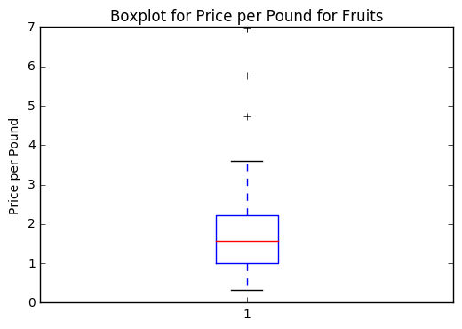

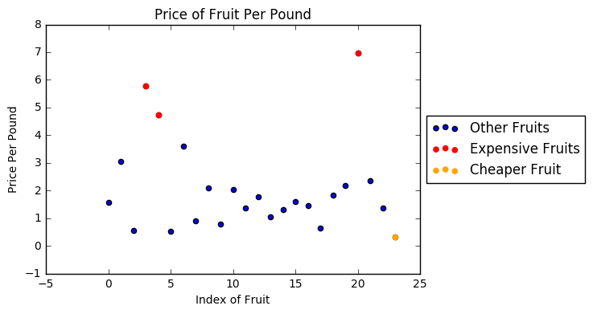

```python
i = 0

#count how many fruits
while (df.typ[i] == 'fruit'):
    i += 1

#x val's
x = range(0, i)

#sort from low to high price per pound
sortfruits = sorted(df.price_per_pound[0:i])
sortvegs = sorted(df.price_per_pound[i:len(df)])

#boxplot
plt.boxplot(df.price_per_pound[0:i], positions = [1])
plt.ylabel('Price per Pound')
plt.title('Boxplot for Price per Pound for Fruits')
plt.show()

#scatter plot
maxfruit = max(df.price_per_pound[0:i])
indexmaxfruit = df.price_per_pound[0:i].argmax()
lowfruit = min(df.price_per_pound[0:i])
indexlowfruit = df.price_per_pound[0:i].argmin()
markers_on = [indexmaxfruit]
plt.scatter(x, df.price_per_pound[0:i], label = "Other Fruits")
plt.scatter(indexmaxfruit, maxfruit, color = "red", label = "Expensive Fruits")
plt.scatter(4, sortfruits[-3], color = "red")
plt.scatter(3, sortfruits[-2], color = "red")
plt.scatter(indexlowfruit, lowfruit, color = "orange", label = "Cheaper Fruit")
plt.ylabel('Price Per Pound')
plt.xlabel('Index of Fruit')
plt.title('Price of Fruit Per Pound')
plt.legend(loc = 'center left', bbox_to_anchor =(1, 0.5))
plt.show()
```

According to the boxplot, there are 3 fruits that are outliers which means they are more than abnormally more expensive than all the other fruits. As for the least expensive fruits, the boxplot does not say that there fruits that are exceptionally less expensive. According to the scatter plot above, it is shown in red dots, the more expensive fruits and they can be found to be blackberries at 5.77 per pound, blueberries at 4.73 per pound and raspberries to be 6.97 per pound. The least expensive fruits is watermelon at 0.33 per pound. If we look for the other relatively cheaper fruits, we notice that bananas and melons are the least expensive fruits whereas berries are the more expensive fruits.

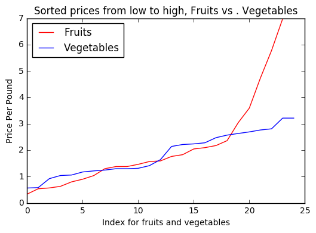

[figure not shown]

```python
#How do the price distributions compare for fruit and vegetables?

y = range(i, len(df))
veg = range(0, len(y))

#plot low to high prices veg and fruits
plt.plot(x, sortfruits, color = "red", label = "Fruits")
plt.plot(veg, sortvegs, color = "blue", label = "Vegetables")
plt.xlabel('Index for fruits and vegetables')
plt.ylabel('Price Per Pound')
plt.title('Sorted prices from low to high, Fruits vs . Vegetables')
plt.legend(loc=2)
plt.show()


#against yeild
plt.scatter(df.yield_[0:i], df.price_per_pound[0:i], color = "red", label = "Fruits")
plt.scatter(df.yield_[i:len(df)], df.price_per_cup[i:len(df)], color = "green", label = "Vegetables")
plt.xlabel('% Yield')
plt.ylabel("Price per Cup")
plt.title('% Yield vs. Price per Cup for Fruits and Vegetables')
plt.legend(loc = 2)
plt.show()
```

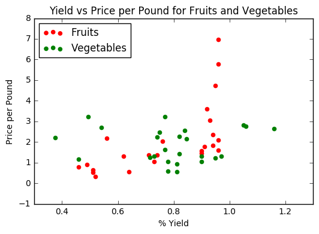

```python
#Which foods are the best value for the price?

#yeild and price per pound for fruits and veg
plt.scatter(df.yield_[0:i], df.price_per_pound[0:i], color = "red", label = "Fruits")
plt.scatter(df.yield_[i:len(df)], df.price_per_pound[i:len(df)], color = "green", label = "Vegetables")
plt.title('Yield vs Price per Pound for Fruits and Vegetables')
plt.xlabel('% Yield')
plt.ylabel('Price per Pound')
plt.legend(loc = 2)
plt.show()
```

In the scatter plot above, we look at the percent yield against the price per pound. The best value for their price has to be the vegetables with more than 100 percent yield because this means you're getting a lot for a price that other vegetables don't yield as much in. These foods are kale, collard greens, and brussel sprouts. The fruits that are the best value are the ones where you get close to 100 percent yielf but the price is similar to other fruits. Berries have almost 100 percent yield but since they are expensive, they are not the best value. The fruits that are the best value are peaches and plums.

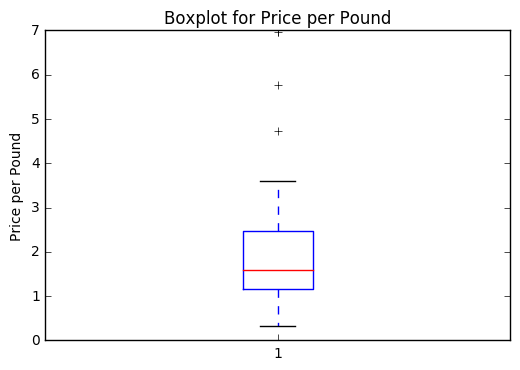

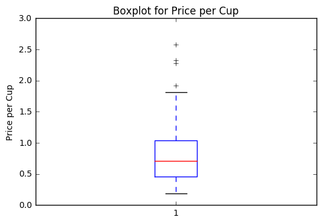

```python
#box plots
plt.boxplot(df.price_per_pound)
plt.ylabel('Price per Pound')
plt.title('Boxplot for Price per Pound')
plt.show()

plt.boxplot(df.price_per_cup, positions = [1])
plt.ylabel('Price per Cup')
plt.title('Boxplot for Price per Cup')
plt.show()
```

Something surprising about this dataset is that the number of outliers are different when we compare prices per pound and price per cup. They should be the same since the cup prices is a ratio of the pound prices. The only reason why there's more outliers is that the margins have shrunk therefore, it's easier for a price to be out of range and thus considered as an outlier. Another surprising thing is that percent yield does not correlate with the price. When we we get more yield, we should expect a more expensive price but that is not the case.

I would expect the foods that are around the median prices to be the most worth for the yield and nutrition because it's not overly expensive. Foods that are expensive create more yield but you can get more with that price you pay whne you buy foods around the median price.